# Lecture 10

## Shiny

Shiny apps consist of 2 components: 1. UI 2. Server

UI is the interface that users see and interact with. What users do on the UI are then sent to the server as an input. The server processes this then sends an output to the UI. The UI processes and shows this output to the user.

### Creating a Shiny App

Create a R script called “app.R”. Note that R automatically recognises this as the base script for the app.

Start with this template:

```
library("shiny")

# Define UI
ui = fluidPage()

# Define server logic
server = function(input, output) {}

# Instantiate app
shinyApp(ui=ui, server=server)
```

### 1. UI

A typical UI usually consists of 2 parts: - Controls (allow user interaction with the system) - Outputs

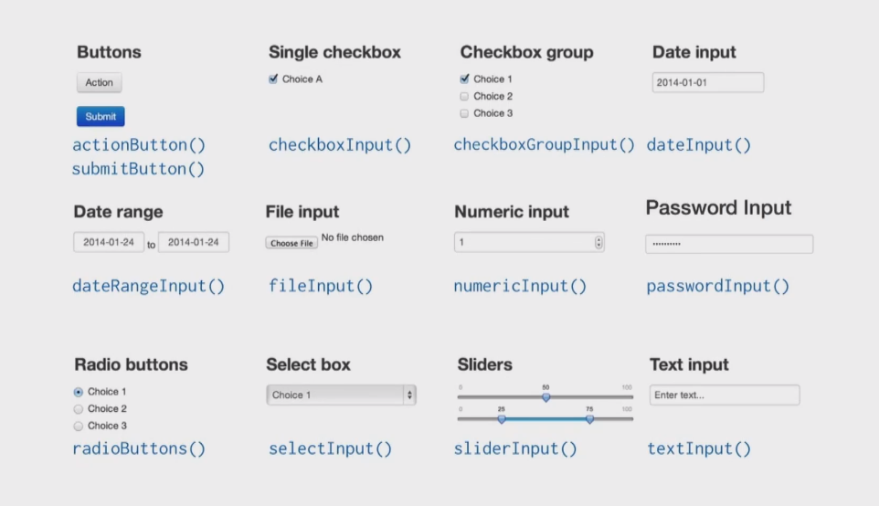

Some controls in Shiny

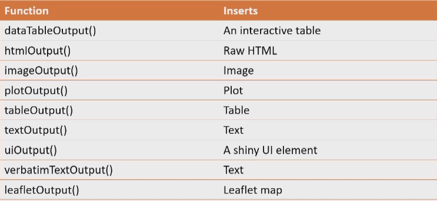

Some outputs in Shiny

```
ui = fluidPage(sliderInput(inputId="zoomlevel", # needs an id to identify
                           label="Map Zooming Level",
                           value=11,
                           min=1,
                           max=20),
               leafletOutput(outputId="plotMap")) # also needs an output id
```

## 2. Server

User actions on UI controls trigger a event. The event passes the corresponding change to the server, which has listeners to react to specific events. The listener then produces the output we expect to see.

```
server = function(input, output){
  output$plotMap = renderLeaflet({ # handle the output
    leaflet() %>% setView(lng=-103,835381, lat=1.239660,
                          zoom=input$zoomlevel %>% # given zoomlevel input
                            addTiles() %>%
                            addMarkers(lng=-103,835381, lat=1.239660,
                                       popup="Sentosa Cove")
  })
}
```

## User Experience

UI should be easy to use and look and feel good to use. We can control how our app looks using layouts.

```
ui = pageWithSidebar(
  # on the top
  headerPanel("How customer's choices on buying health insurance are affected?"),
  # on the side
  sidebarPanel(selectInput(inputId="attribute",
                           label="Customer Attribute",
                           choices=c("housing.type", "sex", "is.employed",
                                     "marital.stat")),
               radioButtons(inputId="position",
                            label="Bar Positioning",
                            choices=c("stack", "dodge", "fill"))),
  # the main display panel
  mainPanel(plotOutput("custPlot"))
)

server = function(input, output) {
  output$custPlot = renderPlot({
    ggplot(custdata) +
      # note that we must use aes_string since input$attribute is a string, not a column
      geom_bar(aes_string(x=input$attribute, fill="is.member"),
               position=input$position)
  })
}
```

## Deploy on a Cloud

Apps can be hosted on a cloud to allow others to use them as well. This is done on shinyapps.io. On the app.R file, click publish app. Upload all relevant files into the same folder.